# Total Least Squares & Ordinary Least Squares

26 September 2021

Return to [blog menu](https://kaihanlee.github.io/blog/) or [homepage](https://kaihanlee.github.io/).

## TLS vs OLS

I am writing this post just for fun and to explore the differences between total least squares (TLS) regression and ordinary least squares (OLS) regression.

I will use two methods to plot the best fit lines for the “cars” data in R.

Note: x is the speed, and y is the distance. Let’s assume that y is dependent on x.

This is the scatterplot for the data, together with the TLS regression line.

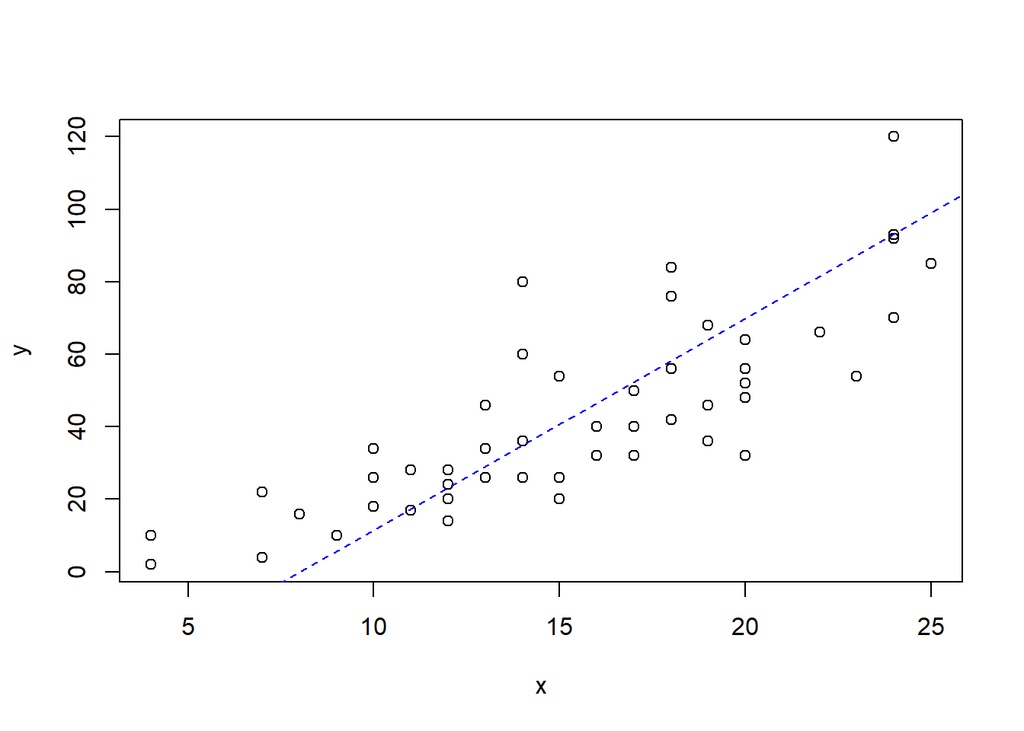

### Assumptions

The error term has a population mean of zero, constant variance, normally distributed, and are independent and identically distributed. This works like [Principal Component Analysis (PCA)](https://en.wikipedia.org/wiki/Principal_component_analysis).

## About TLS

TLS uses orthogonal distance (aka shortest distance or perpendicular offsets) between the data points and the best fit line.

We will use the normal straight line equation with the intercept, a and the slope, b.
$$\begin{align*}
a = \bar y - b \bar x
\end{align*}$$
The values of a and b should minimize the sum of squares of Euclidean distances from the points to the regression line.

Here are the derivations of the equations.

The formula to calculate sum of squares of Euclidean distances is as below, where $d_i$ are Euclidean distances.

$$\begin{align*}
\sum{^n_{i=1}} d_i^2 = \frac{\sum{^n_{i=1}}(y_i-\hat y)^2}{b^2 + 1}
\end{align*}$$
To minimize the above expression, we require
$$\begin{align*}
b = \frac{k + \sqrt{k^2 + h^2}}{h}
\end{align*}$$

where
$$\begin{align*}
k = \sum{^n_{i=1}}(y_i-\bar y)^2 - \sum{^n_{i=1}}(x_i-\bar x)^2
\end{align*}$$
and
$$\begin{align*}
h = 2 \Sigma{^n_{i=1}}(x_i-\bar x)(y_i-\bar y)
\end{align*}$$

### Plot with Regression Line based on TLS

This is the plot with the regression line fitted to minimize total least squares error (same as the first plot above).

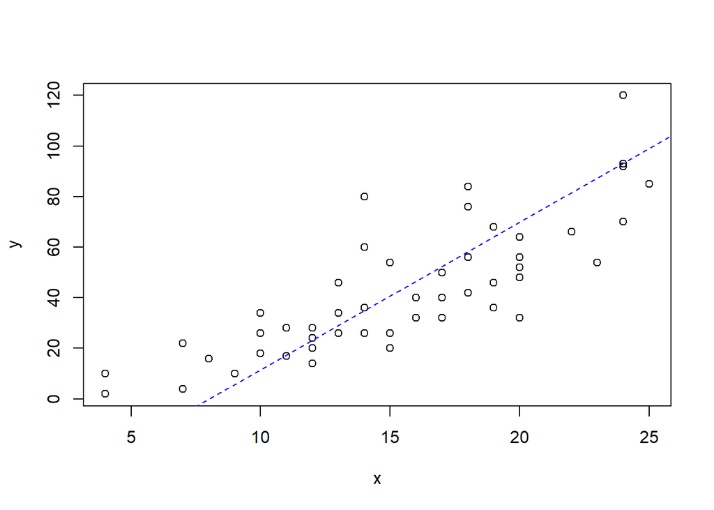

```r
n = length(x)
w = sum((y - mean(y))^2) - sum((x - mean(x))^2)
r = 2 * cov(x, y) * n

b = (w + sqrt(w^2 + r^2))/r
a = mean(y) - mean(x) * b

plot(x, y)
abline(a, b, col = "blue", lty=2)
```

## About OLS

Commonly known as linear regression, just like TLS, but instead of using the Euclidean distance, it takes the difference in y values between the data points and the regression line (vertical offsets), which means this method assumes x values as error-free.

We will also use the normal straight line equation with the intercept, $\alpha$ and the slope, $\beta$, since we are only looking at simple linear regression here.

$$\begin{align*}
\alpha = \bar y - \beta \bar x
\end{align*}$$

Without having to derive formulas due to the calculation of Euclidean distances makes the calculation for the OLS estimators much simpler.

These are the formulas for $\alpha$ and $\beta$.

$$\begin{align*}
\hat \beta = \frac{Cov[x,y]}{Var[x]}
\end{align*}$$

$$\begin{align*}
\hat \alpha = \bar y - \hat \beta \bar x
\end{align*}$$

### Plot with Regression Line based on TLS and OLS

This is the plot with the regression line fitted to minimize total least squares (TLS, blue) error and ordinary least squares (OLS, red) error.

We can use R’s built-in `lm()` function.

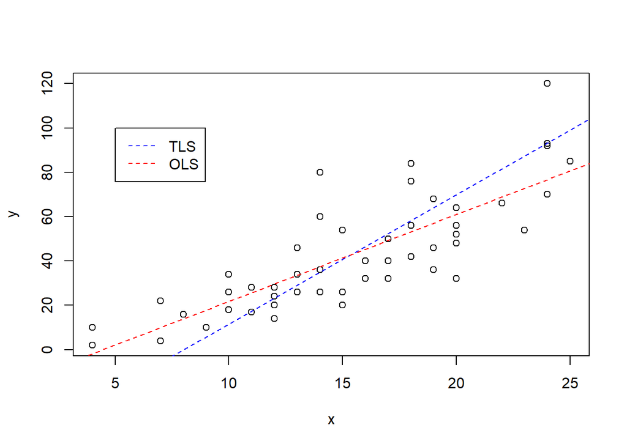

```r
OLS <- lm(y ~ x)
plot(x, y)
abline(a, b, col = "blue", lty=2)
abline(OLS$coefficients, col = "red", lty=2)
legend(5, 100, c("TLS", "OLS"), col = c("blue", "red"), lty=c(2,2))
```

Or plot using the formula above. We get the same results.

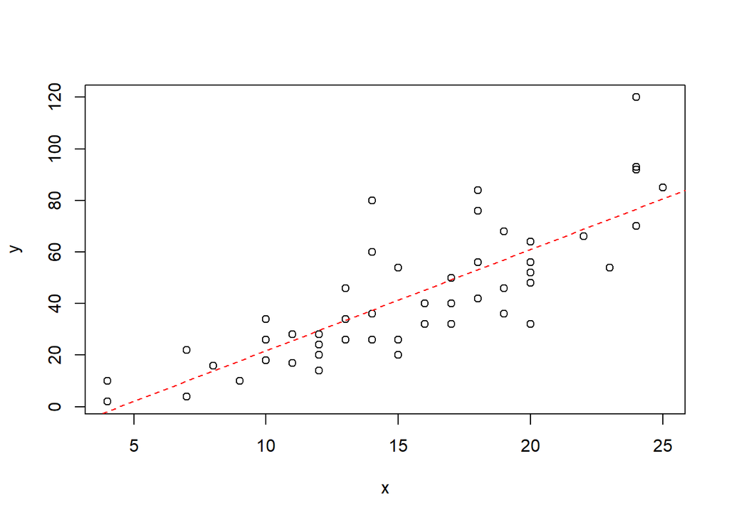

```r
beta <- cov(x, y) / var(x)
alpha <- mean(y) - beta * mean(x)
plot(x, y)
abline(alpha, beta, col = "red", lty=2)
```

Since OLS assumes x values as error-free, the OLS method can be used to constrain the distribution of y. On the other hand, if x, and y are seen to be independent components, we should use TLS.

This is my first try with R Markdown, a huge room to improve.